Theobio main page

# Ontario COVID-19 forecasts

[#MacTheobio COVID Modelling Group](https://mac-theobio.github.io/covid-19/)

Irena Papst ([@irenapapst](https://twitter.com/irenapapst)), Ben Bolker ([@bolkerb](https://twitter.com/bolkerb)), Jonathan Dushoff ([@jd_mathbio](https://twitter.com/jd_mathbio)), David Earn ([@DavidJDEarn](https://twitter.com/davidjdearn))

McMaster University, Hamilton, Ontario, Canada, L8S 4K1

Forecast date: 26 Jan 2022

*Post last updated: 06 Feb 2022*

# Context

Every few weeks, [our group](https://mac-theobio.github.io/covid-19/) provides COVID-19 forecasts for the province of Ontario to the [Ontario Modelling Consensus Table](https://covid19-sciencetable.ca/our-partners/) (MCT), a partner of the [Ontario Science Advisory Table](https://covid19-sciencetable.ca) (SAT), which presents this information to the Health Coordination Table of the Ontario Ministry of Health.[^1] Other modelling groups also provide forecasts to the MCT. After reviewing all forecasts provided, the MCT provides consensus projections to the SAT.

Our forecasts are based on a [compartmental epidemic model](https://en.wikipedia.org/wiki/Compartmental_models_in_epidemiology) implemented in our publicly available [`McMasterPandemic`](https://github.com/bbolker/McMasterPandemic) R package, and involve statistical fits to [Ontario’s latest COVID-19 data](https://covid-19.ontario.ca/data).

# Forecast overview

The forecast presented here was made on **26 Jan 2022** and was submitted to the MCT for inclusion in the SAT’s [update on COVID-19 projections](https://covid19-sciencetable.ca/sciencebrief/update-on-covid-19-projections-16/), released on 1 Feb 2022.

The main goal of this forecast is to explore **possible effects of relaxing some public health measures on future acute care occupancy**. Acute care occupancy is the daily number of patients hospitalized with COVID-19 excluding those in the ICU. The province has taken two reopening steps in January, which we model here: many schools reopened on 18 Jan, and on 31 Jan, the province reopened some venues at 50% capacity (including indoor dining and gyms). We describe the forecast scenarios we considered in detail below.

The projections model **demand for acute care**, which is equivalent to assuming that the province has sufficient resources to meet any future demands on acute care occupancy for COVID-19.

We have updated, and will continue to update, this post in order to show the [latest acute care occupancy](https://covid-19.ontario.ca/data), but the forecasts themselves have not, and will not, be modified after the forecast date.

# Forecast results

The following figure shows projections for **acute care occupancy** (curves) for each **forecast scenario** (colours), with 95% confidence intervals as bands around each projection curve. Observed acute care occupancy to which the model was fit are plotted with **solid points**, while observations after the fact are included as **hollow points**.

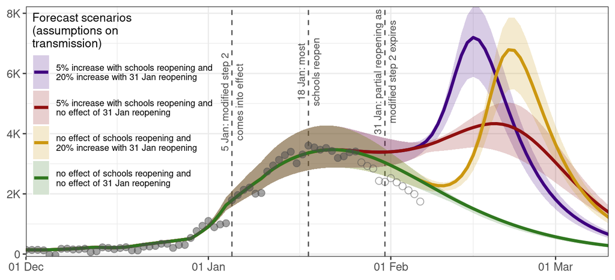

As usual, our projections are *strongly* dependent on the transmission changes assumed to be caused by recent reopening steps. However, there is added uncertainty through the Omicron wave. Tests became much more difficult to obtain after mid-December, due to a surge in demand and limited testing capacity, which meant infection reports became a much worse proxy for transmission. Consequently, from 15 Dec 2021 onward, we calibrated transmission to acute care occupancy only; the uncertainties introduced by this choice are discussed below.

At the time of forecast, our projections demonstrated **a wide variety of possible outcomes for acute care occupancy through February**, including a steady decline, a plateau at the peak during the Omicron wave, or another significant wave (two scenarios). However, with the benefit of the most recent data (hollow points), we see that it is unlikely that transmission increased significantly around 18 Jan 2022, when schools reopened. It remains to be seen whether the province’s 31 Jan reopening has caused a transmission increase that will lead to another wave of hospitalizations in February.

These results also hinge on the **inferred amount of recent infection-based immunity** built up in the population. Based on our assumptions, our model calibrates about 5 million infections between 1 Dec and the calibration end date of 26 Jan. However, this estimated number of infections must be interpreted with caution. Our model assumes random mixing among individuals in the entire population, whereas people in Ontario do not mix randomly but instead interact mostly with their social network. Compared with random mixing, the true pattern of mixing in the province offers some protective benefit to individuals by constraining their exposure to the virus. Thus, in order to reproduce the observed patterns in acute care occupancy, the random mixing model calibrates more natural immunity in the population than there probably is in reality.

# Forecast and model details

## Forecast scenarios

The focus of our forecast is to examine possible outcomes for acute care occupancy through the month of February. Acute care occupancy of COVID-19 is the daily number of individuals in hospital with COVID-19 excluding those in the ICU.

There are at least two factors that may affect acute care occupancy through this period: **schools reopening on 18 Jan** and **modified step 2 expiring on 31 Jan**. Neither possible effect would be reflected in the acute care occupancy data up to the calibration date—due to the delay between transmission and severe illness, and because step 2 expired after our calibration—so we cannot infer the magnitude of these effects from data yet. Instead, we construct forecast scenarios by making assumptions about the effect of each of these changes.

For each forecast scenario we choose one option for the effect of schools on transmission and one option for the effect of 31 Jan reopening:

- no effect of schools reopening or 5% increase with schools reopening;
- no effect of 31 Jan reopening or 20% increase with 31 Jan reopening.

The combination of these options yields four forecast scenarios:

1. no effect of schools reopening and no effect of 31 Jan reopening (a status quo forecast)
2. no effect of schools reopening and 20% increase with 31 Jan reopening
3. 5% increase with schools reopening and no effect of 31 Jan reopening
4. 5% increase with schools reopening and 20% increase with 31 Jan reopening

The specific choices for the percent change in transmission are arbitrary but chosen to **illustrate some possibilities for schools reopening and modified step 2 expiry**. It is also important to note that we are not specifically modelling either of these changes in any detail, but instead we are assuming that there may or may not be some average population-level change in transmission on the dates associated with these reopening steps. In reality, reopening is unlikely to affect people’s behaviour uniformly across the province.

For instance, if 31 Jan reopening primarily changes the behaviour of healthier, boosted individuals in the province (because they feel safer in riskier settings like indoor dining), then any initial transmission increase would occur in this subpopulation, which is unlikely to provoke an increase in acute care occupancy given the risk of severe disease in these individuals is lower than average. However, transmission might leak out from this subpopulation over time and move into more vulnerable ones, like the unvaccinated or the elderly, at which point we may observe an increase in acute care occupancy. In this case, acute care occupancy would follow a trajectory that is delayed and perhaps flatter compared to the projection in scenario 2.

## Uncertainties in model calibration

One of the main uncertainties in projecting infection reports and acute care occupancy for Ontario currently is that **the degree of transmission reduction achieved by the [19 Dec](https://news.ontario.ca/en/release/1001366/ontario-further-strengthening-response-to-omicron) and [5 Jan](https://news.ontario.ca/en/release/1001394/ontario-temporarily-moving-to-modified-step-two-of-the-roadmap-to-reopen) public health measures is not known**. Without a firm grasp of the amount of Omicron transmission that has already occurred during the current wave, it is impossible to know with any certainty the amount of infection-based immunity in the population. **The repercussions of 31 Jan reopening depend strongly on the level of newly-acquired infection-based immunity in the population** as well as the continued rollout of third doses to bolster population-level immunity.

It is **difficult to calibrate the current level of population immunity** since the demand for PCR tests surged past our provincial testing capacity in mid-December, leading to [restricted testing in the general population](https://news.ontario.ca/en/backgrounder/1001387/updated-eligibility-for-pcr-testing-and-case-and-contact-management-guidance-in-ontario) and increased underreporting of infections. As a result, we do not calibrate to infection reports after 15 Dec, but we still calibrate transmission indirectly using acute care occupancy data up to 26 Jan.

Using acute care occupancy to infer transmission introduces additional uncertainty in our fit (and therefore forecast) as there is the **added unknown of Omicron severity**, which we define as the percentage of infections severe enough to require hospitalization. One approach would be to use our model to calibrate Omicron severity as the proportion of model-inferred infections that are hospitalized, but there is a tremendous amount of uncertainty in the number of Omicron infections that have occurred due to recently-limited testing data, as discussed above.

To infer absolute Omicron severity, we instead calibrate Delta severity (an estimated 3% of infections are hospitalized) and scale it using an estimate of Omicron’s severity relative to Delta from a [Public Heath Ontario (PHO) study](https://www.publichealthontario.ca/-/media/documents/ncov/epi/covid-19-epi-enhanced-estimates-omicron-severity-study.pdf?sc_lang=en) (Omicron’s severity is approximately 43% of Delta’s). Therefore, we assume about 1.3% of Omicron infections are severe.

Moreover, as Omicron spread widely through the province in January, the prevalence of **“incidental” COVID hospital admissions** increased: these are patients admitted to hospital for a reason unrelated to COVID (*e.g.,* labour and delivery), but the patient tested positive upon admission. If we were to calibrate directly to hospitalizations using our inferred Omicron severity, we would drastically overpredict the amount of Omicron transmission underlying the current hospitalization wave, as not all COVID-positive hospitalizations have severe COVID.

In an attempt to rectify this issue, we assume that [50% of COVID-positive hospital admissions were incidental](https://twitter.com/celliottability/status/1483458298565337103) starting on 4 Jan, and calibrate our model to just the 50% of hospitalizations that we assume are severe. **The precise choice of percentage of incidental COVID hospitalizations greatly affects our projections**. If the assumed incidental percentage were to be much lower in the model than the true percentage, we would be assuming more severe COVID infections, which, for a fixed severity would mean more underlying spread of Omicron. These assumptions could lead to more optimistic forecasts for 31 Jan reopening as the model then predicts more recent infection-based immunity. The opposite is also true: if we have assumed an incidental percentage that is much higher than the true percentage, our forecasts then project a much worse picture for 31 Jan reopening than may actually come to pass.

## Infection

### Transmission

We assume that the transmission rate is piecewise constant through the fit period, selecting re-estimation dates for this rate based on large-scale changes in public health measures (*e.g.,* a stay-at-home order or a major reopening step) or when it appears individual behaviour may be changing. By assuming that the transmission rate is constant between re-estimation dates, we capture the **average effect of any changes in transmission** over the entire period between these dates.

### Resetting immunity from prior infection

To approximate the effects of **waning immunity** from prior infection, we ignore infections that occurred before March 2021. This is a “hard reset” of natural immunity: it is possible that some individuals are still protected by early infections, so this assumption is a worst-case scenario.

### Reinfection

Our model does not account for **reinfections** after March 2021, which includes individuals first infected with Delta being reinfected with Omicron. As a result, the build up of population-level immunity from infection before the calibration date may be overestimated by our model, which would make reopening on 31 Jan seem safer than it may actually be.

## Vaccination

### Adding boosters

Our model structure currently involves the administration of only two vaccine doses. In order to add boosters into our two-dose model, **we assume that first doses have no effect**, so that we may input second doses as the first dose and boosters as the second dose.

The assumption that first doses have no effect is sensible in the context of Ontario’s COVID epidemic: the period of time over which the majority of vaccinated individuals were protected by only one vaccine dose overlapped largely with the Delta wave in spring 2021. First-dose vaccine efficacy against Delta infection is estimated to be only 30%, so we believe the number of individuals that were protected against infection by one dose of vaccine is likely to be small, so this would not change our model calibration significantly.

### Other vaccination assumptions

We assume that **two-dose infection-blocking vaccine efficacy** (VE) is **90%** against the **Alpha** variant, **80%** against **Delta**, and **30%** against **Omicron**. After **three doses**, protection against **Delta** rises to **95%** and to **70%** against **Omicron**. We do not model waning of booster protection. We adjust effective vaccine efficacy depending on the proportion of infections due to each variant inferred every day.

Vaccine-derived immunity takes an average of 14 days to develop after a dose is administered in the model.

Vaccines are **administered at random** in the population (as opposed to in an age-based way). We use the actual number of each dose administered per day through the forecast period, as reported by covid19tracker.ca. We project the administration of vaccines through the forecast period by continuing the most recent dose-administration trends. We assume that **second doses saturate to 90%** of the eligible population and **third doses saturate to 85%**. (Our vaccine projection model predicts the administration of about 8M boosters in total by the end of February.)

## Omicron variant

We introduce the Omicron variant into the population on 29 Nov 2021 at a frequency of 1% of all infection reports, based on [early estimates of Omicron prevalence via S-gene target failure from PHO](https://www.publichealthontario.ca/-/media/documents/ncov/epi/covid-19-omicron-weekly-epi-summary.pdf?sc_lang=en). We assume that Omicron has a selective advantage of 0.3/day over Delta ([based on estimates from PHO](https://www.publichealthontario.ca/-/media/documents/ncov/epi/covid-19-early-dynamics-omicron-ontario-epi-summary.pdf?sc_lang=en)), which induced the takeover of Delta by Omicron. We model the takeover of Delta by Omicron with a logistic function based on [Day & Gandon 2007](https://doi.org/10.1111/j.1461-0248.2007.01091.x).

## Data

Infection reports and acute care occupancy counts are taken from the [Status of COVID-19 Cases in Ontario](https://data.ontario.ca/en/dataset/status-of-covid-19-cases-in-ontario) dataset in the [Ontario Data Catalogue](https://data.ontario.ca) (acute care occupancy is calculated by subtracting the daily number of COVID-19 patients in the ICU from the daily number of individuals hospitalized with COVID-19).

We calibrate to infection report data only up to 15 Dec, the date when we estimate that testing demand began to significantly outweigh supply; after 15 Dec, underreporting likely increased dramatically, biasing the signal from these data. We calibrate acute care occupancy up to 26 Jan.

We use vaccination data as reported by covid19tracker.ca, which aggregates data from [individual Public Health Units in the province](https://covid19tracker.ca/ontario.html).

Related post: [Ontario COVID-19 forecasts, 26 Nov 2021](https://mac-theobio.github.io/forecasts/outputs/McMasterOntarioForecastsBlog2021-11-26)

[Back to the MacTheobio COVID Modelling Group page](https://mac-theobio.github.io/covid-19/)

[^1]: This report has been written independently of the Ontario Modelling Consensus Table, the Ontario Science Advisory Table, and the Health Coordination Table. The views expressed in this report are solely the authors’.